# Subgroup-Method Signature Recovery (Two-Factor)

Matched harm-subgroup recovery for FS-consistency, FS-grf (tree and frontier), and standalone DINA on a two-factor conjunction DGM (depth-2 / maxk = 2)

Author

forestsearch v0.2.0

Published

June 3, 2026

# 1 Purpose

The companion document studies a DGM whose true signature is a **single covariate threshold** – ideal for the univariate `dina_subgroup()` search and for `forestsearch(maxk = 1)`. This document studies the **two-factor analog**: the true harm subgroup is an **AND-conjunction of two covariates**, and both identifiers are given the matching hypothesis space:

- `forestsearch(maxk = 2)` — allowed to combine up to two factors.
- `dina_subgroup(max_depth = 2)` — allowed to select a two-covariate conjunction (the depth-2 extension), not just a univariate threshold.

Both methods are run on the **same simulated data** each replication and scored against the **same** ground-truth conjunction. The DGM mirrors the single-factor setup: covariates $\sim U[-1,1]$, logistic propensity, Cox outcome via `rexp(rate = exp(eta))` with uniform censoring, and a true harm subgroup

$$S = \{x_1 \ge c_1 \ \text{and}\ x_2 \le c_2\}$$

(treatment increases the hazard inside $S$). The conjunction uses **mixed directions** ($x_1$ from the right, $x_2$ from the left) to exercise mixed-direction depth-2 selection.

## 1.1 Matched thresholds (harm study)

The methods use the **same harm cutoff on the natural (HR) scale**:

[output not shown]

## 1.2 Fairness: the `maxk` / `max_depth` knob

The true signature is **two factors**. Here both methods are given the two-factor hypothesis space (`fs_maxk = 2L`, `dina_max_depth = 2L`), so the comparison is like-for-like against the conjunction truth. Setting either back to 1 reproduces the single-factor restriction of the companion study and shows the cost of under-fitting a genuine two-factor signature.

## 1.4 GRF arms: `forestsearch(subgroup_method = "grf")` (tree and frontier)

Alongside the consistency-search FS arm and standalone DINA, the study includes **two GRF-selection arms**, both via `forestsearch(subgroup_method = "grf")` on the same causal-survival-forest doubly-robust scores, differing only in how the subgroup is selected from those scores:

- **`FS-grf-tree`** (`grf_selection = "tree"`, the default) selects via the GRF policy tree under `dmin.grf` / `grf_depth`. At `grf_depth = 2` the tree *partitions*, so its harm region may be a single leaf (a conjunction) or a union of leaves (a disjunction).
- **`FS-grf-frontier`** (`grf_selection = "frontier"`, experimental) selects from the Pareto frontier of (harm-effect, size) on the same scores. With `grf_depth = 2` the candidate pool is single-covariate thresholds **plus depth-2 covariate-pair conjunctions**, and selection uses the **effMaxSG** rule (largest within `effect_neighborhood` of the max harm-effect). The selected subgroup is always a single conjunction (never a union). Only the effMaxSG variant is run here.

Neither arm varies a rule across rows (the tree ignores `sg_focus`; the frontier fixes effMaxSG), so each contributes one row per replication. Comparing them isolates the selection step alone – policy tree vs Pareto frontier – holding the forest fit fixed, on a truth (`x1 >= 0 & x2 <= 0`) that genuinely needs two factors.

Because GRF membership is taken from the selected subgroup, the membership-based recovery metrics (sensitivity, specificity, PPV, NPV) are always well defined. The text-parsing metrics (`cov-set hit`, `sig correct`, `mean #factors`) apply cleanly to a single conjunction; when the tree arm returns a **union** of leaves they are reported as `NA` (a union has no single signed-axis signature). The frontier arm is always a single conjunction, so those metrics always apply to it.

# 2 Configuration

```r
library(forestsearch)
library(survival)
library(data.table)
library(gt)
library(ggplot2)
library(doFuture)
library(foreach)

# Graphics utilities (OC-bubble vocabulary shared with the binary_m1_harm
# summary).  Resolve _utils whether rendering from the package root or from
# within quarto/<subdir>/.
.util_dir <- "../_utils"
if (!dir.exists(.util_dir)) .util_dir <- file.path("..", "..", "_utils")
source(file.path(.util_dir, "signature_recovery_display.R"))
source(file.path(.util_dir, "plot_oc_metrics.R"))
source(file.path(.util_dir, "compute_oc_pareto_flag.R"))

CONFIG <- list(
  # Monte Carlo
  nsims       = 1000L,          # replications per cell (scale up for production)
  base_seed   = 20260531L,

  # design grid (forestsearch is expensive; keep modest)
  d           = 5L,
  n_levels    = c(500L, 750L, 1000L),
  tau_in      = c(moderate = 0.9, strong = 1.4),  # harm log-HR inside S
  tau_out     = 0.0,

  # ---- true two-factor conjunction signature ----
  #   S = { x1 >= 0  AND  x2 <= 0 }  (mixed directions)
  true_covs = c("x1", "x2"),
  true_dirs = c("right", "left"),
  true_cuts = c(0.0, 0.0),

  cox_T0      = 1.5,           # uniform-censoring upper bound (DGM and fits match)

  # ---- matched harm thresholds (natural scale) ----
  effect_threshold = 1.75,
  m_diff           = log(1.75),

  # ---- forestsearch knobs ----
  fs_maxk            = 2L,     # two-factor hypothesis space (matched to truth)
  fs_foci            = c("eff", "effMaxSG", "effMinSG"),  # NEW: both selection rules
  fs_eff_neighbor    = 0.10,
  fs_selection_rule  = "neighborhood",
  fs_consistency     = 1.5,
  fs_pconsistency    = 0.90,
  fs_subgroup_method  = "consistency",
  fs_splits          = 1000L,
  fs_n_min           = NULL,
  fs_d0_min          = 10L,
  fs_d1_min          = 10L,
  fs_vi_grf_min      = -0.2,
  fs_use_grf         = TRUE,
  fs_use_lasso       = TRUE,
  fs_use_dina        = TRUE,
  fs_seedit          = 8316951L,
  # fs_dina_args = list(
  #          seed        = seed,
  #          n_folds     = cfg$dina_n_folds,
  #          cens_type   = "uniform",
  #          cens_params = list(T0 = cfg$cox_T0),
  #          max_depth   = cfg$dina_max_depth,
  #          grid_probs  = cfg$dina_grid_probs
  #        ),
  # use defaults
  fs_dina_args = list(),

  # ---- FS-grf knobs (subgroup_method = "grf"): GRF policy-tree selection.
  #   GRF selects via the policy tree / dmin.grf, NOT the sg_focus
  #   effect-neighborhood rule, so FS-grf is a SINGLE run per replication
  #   (one row, method "FS-grf"), not a per-focus loop.  grf_depth = 2 is the
  #   forestsearch() default and matches the two-factor truth.
  fs_grf_enable   = TRUE,
  fs_grf_frontier = TRUE,      # also run GRF frontier-selection (effMaxSG)
  fs_grf_depth    = 2L,        # GRF tree depth (forestsearch() default)
  # Three independent dmin.grf knobs, one per GRF use (all on the RMST /
  # time-unit scale for survival -- NOT the HR scale; see the scale note in
  # the GRF-arms section).  All default to 0.0, reproducing prior behavior;
  # raise a single one to calibrate that use (e.g. the frontier's FDR)
  # without moving the others.
  fs_grf_screen_dmin   = 0.0,  # screening cut-generation (FS-eff / FS-effMaxSG)
  fs_grf_tree_dmin     = 0.35,  # GRF policy-tree selection  (FS-grf-tree)
  fs_grf_frontier_dmin = 0.35,  # GRF frontier selection     (FS-grf-frontier)
  fs_grf_fractau  = 0.60,      # GRF time-horizon multiplier (survival)

  # ---- dina_subgroup knobs ----
  dina_n_folds   = 2L,
  dina_n_min     = NULL,
  dina_alpha     = 0.05,
  dina_max_depth = 2L,                          # depth-2 conjunction selection
  dina_grid_probs = seq(0.1, 0.9, by = 0.1),    # per-covariate threshold grid
  dina_foci      = c("eff", "effMaxSG", "effMinSG"),
  dina_eff_neighbor = 0.10,

  # parallel
  parallel       = "sims",     # "sims" or "none"
  n_workers_frac = 0.9,
  n_workers      = NULL
)

stopifnot(abs(exp(CONFIG$m_diff) - CONFIG$effect_threshold) < 1e-8)
stopifnot(CONFIG$fs_maxk %in% c(1L, 2L), CONFIG$dina_max_depth %in% c(1L, 2L))
stopifnot(length(CONFIG$true_covs) == 2L,
          length(CONFIG$true_dirs) == 2L,
          length(CONFIG$true_cuts) == 2L)
stopifnot(all(CONFIG$fs_foci %in%
              c("maxSG","minSG","eff","effMaxSG","effMinSG")))
stopifnot(all(CONFIG$dina_foci %in%
              c("maxSG","minSG","eff","effMaxSG","effMinSG")))
stopifnot(CONFIG$m_diff > CONFIG$tau_out, all(CONFIG$m_diff < CONFIG$tau_in))

`%||%` <- function(a, b) if (is.null(a)) b else a
```

## 2.1 Parallel plan

```r
if (CONFIG$parallel == "sims") {
  total_cores <- parallelly::availableCores()
  n_workers <- if (is.null(CONFIG$n_workers))
    max(1L, as.integer(floor(CONFIG$n_workers_frac * total_cores)))
  else as.integer(CONFIG$n_workers)
  future::plan(future::multisession, workers = n_workers)
  message(sprintf("Parallel plan: %d workers of %d cores", n_workers, total_cores))
} else {
  future::plan("sequential"); n_workers <- 1L
  message("Parallel plan: sequential")
}

timings <- list()
```

# 3 Data-generating mechanism

A genuine two-factor harm subgroup via a step in the treatment effect: $\tau(x) = \tau_{\text{in}}$ (harm) inside the conjunction $S = \{x_1 \ge c_1 \ \text{and}\ x_2 \le c_2\}$, and $\tau_{\text{out}} = 0$ outside. For the null arm both are zero. The data frame carries the true membership column `flag_harm` for scoring but does not expose the cuts to either method.

```r
simulate_conjunction_cox <- function(n, d, tau_in, tau_out,
                                      true_covs, true_dirs, true_cuts, cox_T0) {
  X <- matrix(stats::runif(n * d, -1, 1), n, d)
  colnames(X) <- paste0("x", seq_len(d))

  e_x <- stats::plogis(0.3 * X[, 1])
  W   <- stats::rbinom(n, 1L, e_x)

  in_S <- rep(TRUE, n)
  for (j in seq_along(true_covs)) {
    xj <- X[, true_covs[j]]
    in_S <- in_S & (if (true_dirs[j] == "left") xj <= true_cuts[j]
                    else xj >= true_cuts[j])
  }
  tau_x <- tau_out + (tau_in - tau_out) * as.numeric(in_S)

  mu_x  <- 0.2 * X[, 1] - 0.1 * X[, 2]
  eta_w <- mu_x + W * tau_x

  t_event  <- stats::rexp(n, rate = exp(eta_w))
  t_censor <- stats::runif(n, 0, cox_T0)

  data.table(
    id        = seq_len(n),
    y_sim     = pmin(t_event, t_censor),
    event_sim = as.integer(t_event <= t_censor),
    treat_sim = W,
    flag_harm = as.integer(in_S),
    as.data.frame(X)
  )
}
```

# 4 Scoring (common, method-agnostic)

Both methods may return a multi-factor rule, so both are scored on **method-agnostic** quantities: detection, membership recovery vs the true mask (sensitivity / specificity / PPV / NPV), the number of factors returned, and two signature-identity flags — whether the discovered rule uses exactly the true **covariate set** (`covariate_set_hit`) and exactly the true **(covariate, direction)** axes (`signature_correct`). For `dina_subgroup()`, where the axes are explicit, per-component threshold bias is also reported when the axes are correct.

## 4.1 Classification metrics under HTEs (H1)

Under the alternative the true harm subgroup $S$ exists ($S = \{x_1 \ge 0 \cap x_2 \le 0\}$, prevalence $\approx 25\%$) with a genuinely different treatment effect. Following León et al. (2024, Section 3), define for the estimated subgroup $\hat{S}$:

$$\text{sens}(\hat{S}) = \frac{\#\{i \in \hat{S} \cap S\}}{\#\{i \in S\}},
\qquad
\text{ppv}(\hat{S}) = \frac{\#\{i \in \hat{S} \cap S\}}{\#\{i \in \hat{S}\}},$$

with the analogous measures for the complement $\hat{S}^c$ (the subgroup predicted *not* to be harmed — here, the benefiting/neutral region). The operating-characteristic columns report:

| Column | León et al. notation | Interpretation |
| --- | --- | --- |
| **sens** | $\text{sens}(\hat{S})$ | Fraction of true $S$ captured by $\hat{S}$ |
| **spec** | $\text{sens}(\hat{S}^c)$ | Fraction of true $S^c$ correctly in $\hat{S}^c$ |
| **ppv** | $\text{ppv}(\hat{S})$ | Fraction of $\hat{S}$ truly in $S$ |
| **npv** | $\text{ppv}(\hat{S}^c)$ | Fraction of $\hat{S}^c$ truly in $S^c$ |

So **sens / ppv** characterise the accuracy of the *identified* harm subgroup $\hat{S}$, while **spec / npv** characterise the accuracy of its *complement* $\hat{S}^c$ — the region declared to benefit. Classification metrics are averaged across **all** non-null replications (León et al. 2024, Table 1); when no subgroup is detected ($\hat{S} = \emptyset$), everyone is assigned to $\hat{S}^c$, so that replication contributes $\text{sens}(\hat{S}) = 0$ and $\text{ppv}(\hat{S}) = 0$.

**NoteDiscovered cuts vs oracle cuts**

```r
mask_recovery <- function(disc_mask, true_mask) {
  tp <- sum(disc_mask & true_mask); fp <- sum(disc_mask & !true_mask)
  fn <- sum(!disc_mask & true_mask); tn <- sum(!disc_mask & !true_mask)
  safe <- function(a, b) if (b > 0) a / b else NA_real_
  list(sensitivity = safe(tp, tp + fn), specificity = safe(tn, tn + fp),
       ppv = safe(tp, tp + fp), npv = safe(tn, tn + fn),
       jaccard = safe(tp, tp + fp + fn))
}

# Empty/standard per-method result row (keeps rbindlist columns aligned).
# te_1 / te_2 are per-component threshold errors aligned to true_covs order.
empty_row <- function(method) data.table(
  method = method, found = FALSE,
  covariate_set_hit = NA, signature_correct = NA,
  n_subgroup = NA_integer_, n_factors = NA_integer_,
  te_1 = NA_real_, te_2 = NA_real_,
  sensitivity = NA_real_, specificity = NA_real_, ppv = NA_real_,
  npv = NA_real_, jaccard = NA_real_, sg_def = NA_character_,
  fit_seconds = NA_real_
)

# When nothing is found and the cell is non-null: everyone predicted Hc.
.fill_none <- function(out, df, truth) {
  if (!truth$is_null) {
    true_H <- df[[truth$mask_col]] == 1L
    npv_none <- if (length(true_H)) mean(!true_H) else NA_real_
    out[, c("sensitivity","specificity","ppv","npv","jaccard") :=
          .(0, 1, 0, npv_none, 0)]
  }
  out
}

# Does the discovered text use every true covariate (whole-word)?
.covset_in_text <- function(sg_txt, true_covs) {
  all(vapply(true_covs, function(cv)
    grepl(paste0("\\b", cv, "\\b"), sg_txt), logical(1)))
}

# Parse a forestsearch sg.harm definition into the set of signed axes it uses,
# as "covariate direction" strings.  Handles negation: "!{x1 <= 0.5}" is
# NOT(x1 <= 0.5) = (x1 > 0.5), i.e. the "right" direction on x1.  Returns
# NA_character_ if any factor cannot be parsed (e.g. a categorical/level cut),
# so signature_correct falls back to NA rather than a wrong value.
.parse_fs_axes <- function(sg_txt) {
  toks  <- strsplit(sg_txt, " & ", fixed = TRUE)[[1]]
  pairs <- character(0)
  for (t in toks) {
    neg  <- startsWith(trimws(t), "!")
    body <- gsub("[!{} ]", "", t)
    m <- regmatches(body,
                    regexec("^([A-Za-z0-9_.]+)(<=|>=|<|>)(.*)$", body))[[1]]
    if (length(m) != 4L) return(NA_character_)
    dir <- if (m[3] %in% c("<=", "<")) "left" else "right"
    if (neg) dir <- if (dir == "left") "right" else "left"
    pairs <- c(pairs, paste(m[2], dir))
  }
  pairs
}

# Score forestsearch: discovered membership is treat.recommend == 0 (-> H).
score_fs <- function(fs, df, truth, method_label = "FS") {
  out <- empty_row(method_label)
  sg <- tryCatch(fs$grp.consistency$sg.harm, error = function(e) NULL)
  found_flag <- !is.null(sg) && length(sg) > 0 && !all(is.na(sg))
  out[, found := found_flag]
  if (!found_flag) return(.fill_none(out, df, truth))

  sg_txt <- paste(sg[!is.na(sg)], collapse = " & ")
  out[, sg_def := sg_txt]

  # A GRF union of leaves is carried as a single disjunctive definition string
  # "(a & b) | (c & d)".  Membership-based metrics (sens/spec/ppv/npv) are
  # always valid because they read treat.recommend, but the text-parsing
  # metrics (n_factors, covariate_set_hit, signature_correct) do not have a
  # clean single-conjunction meaning for a union, so flag them NA rather than
  # mis-parse the disjunction.
  is_disjunction <- length(sg) == 1L && grepl("|", sg, fixed = TRUE)

  if (is_disjunction) {
    out[, n_factors := NA_integer_]
    if (!truth$is_null) {
      out[, covariate_set_hit := NA]
      out[, signature_correct := NA]
    }
  } else {
    out[, n_factors := sum(!is.na(sg))]
    if (!truth$is_null) {
      out[, covariate_set_hit := .covset_in_text(sg_txt, truth$covariates)]
      # Signed-axis recovery for forestsearch, parsed from the cut labels
      # (negations flip the direction).  NA if any label is unparseable.
      fs_axes <- .parse_fs_axes(sg_txt)
      out[, signature_correct := if (length(fs_axes) == 1L && is.na(fs_axes[1]))
            NA else setequal(fs_axes, paste(truth$covariates, truth$directions))]
    }
  }

  df_est <- tryCatch(fs$df.est, error = function(e) NULL)
  if (!is.null(df_est) && "treat.recommend" %in% names(df_est)) {
    disc <- df_est$treat.recommend == 0
    if (length(disc) == nrow(df) && !truth$is_null) {
      true_mask <- df[[truth$mask_col]] == 1L
      rec <- mask_recovery(disc, true_mask)
      out[, c("sensitivity","specificity","ppv","npv","jaccard") :=
            .(rec$sensitivity, rec$specificity, rec$ppv, rec$npv, rec$jaccard)]
      out[, n_subgroup := sum(disc)]
    }
  }
  out
}

# Score dina_subgroup (depth-1 or depth-2; covariate/direction/threshold may
# be length-1 or length-2 vectors).  Membership recovery uses sg$mask, which is
# depth-agnostic.  `method_label` tags rows per sg_focus run.
score_dina <- function(sg, df, truth, method_label = "DINA") {
  out <- empty_row(method_label)
  found_flag <- !is.null(sg) && isTRUE(sg$found)
  out[, found := found_flag]
  if (!found_flag) return(.fill_none(out, df, truth))

  covs <- as.character(sg$covariate)
  dirs <- as.character(sg$direction)
  thr  <- as.numeric(sg$threshold)
  out[, n_factors := length(covs)]
  out[, n_subgroup := as.integer(sg$n_subgroup)]
  out[, sg_def := sg$label %||%
        paste(sprintf("%s %s %.3f", covs,
                      ifelse(dirs == "left", "<=", ">="), thr),
              collapse = " & ")]

  if (!truth$is_null) {
    out[, covariate_set_hit := setequal(covs, truth$covariates)]
    sig_disc <- paste(covs, dirs)
    sig_true <- paste(truth$covariates, truth$directions)
    sig_ok   <- setequal(sig_disc, sig_true)
    out[, signature_correct := sig_ok]
    if (sig_ok) {
      idx <- match(truth$covariates, covs)        # align components by name
      te  <- thr[idx] - truth$cuts
      out[, te_1 := te[1]]; out[, te_2 := te[2]]
    }
    true_mask <- df[[truth$mask_col]] == 1L
    rec <- mask_recovery(as.logical(sg$mask), true_mask)
    out[, c("sensitivity","specificity","ppv","npv","jaccard") :=
          .(rec$sensitivity, rec$specificity, rec$ppv, rec$npv, rec$jaccard)]
  }
  out
}
```

## 4.2 Scoring unit tests

```r
.ok <- function(lbl, cond) cat(if (isTRUE(cond)) "PASS" else "FAIL", "-", lbl, "\n")

tm <- c(rep(TRUE, 30), rep(FALSE, 70))
.ok("perfect mask sens=1", isTRUE(all.equal(mask_recovery(tm, tm)$sensitivity, 1)))
```

```
PASS - perfect mask sens=1
```

```r
.ok("perfect mask spec=1", isTRUE(all.equal(mask_recovery(tm, tm)$specificity, 1)))
```

```
PASS - perfect mask spec=1
```

```r
# mock data with a true conjunction S = {x1 >= 0 & x2 <= 0}
set.seed(1)
mock <- data.table(x1 = runif(200, -1, 1), x2 = runif(200, -1, 1))
mock[, flag_harm := as.integer(x1 >= 0 & x2 <= 0)]
truthC <- list(is_null = FALSE, covariates = c("x1", "x2"),
               directions = c("right", "left"), cuts = c(0, 0),
               mask_col = "flag_harm")

# correct depth-2 DINA selection (axes + cuts exactly right)
mock_sg2 <- list(found = TRUE, depth = 2L,
                 covariate = c("x1", "x2"), direction = c("right", "left"),
                 threshold = c(0, 0), n_subgroup = sum(mock$flag_harm),
                 label = "{x1 >= 0 & x2 <= 0}",
                 mask = mock$x1 >= 0 & mock$x2 <= 0)
sd2 <- score_dina(mock_sg2, mock, truthC, "DINA-effMaxSG")
.ok("dina depth-2: covariate_set_hit TRUE", isTRUE(sd2$covariate_set_hit))
```

```
PASS - dina depth-2: covariate_set_hit TRUE
```

```r
.ok("dina depth-2: signature_correct TRUE", isTRUE(sd2$signature_correct))
```

```
PASS - dina depth-2: signature_correct TRUE
```

```r
.ok("dina depth-2: te aligned ~ 0", isTRUE(abs(sd2$te_1) < 1e-9 && abs(sd2$te_2) < 1e-9))
```

```
PASS - dina depth-2: te aligned ~ 0
```

```r
.ok("dina depth-2: sensitivity = 1", isTRUE(all.equal(sd2$sensitivity, 1)))
```

```
PASS - dina depth-2: sensitivity = 1
```

```r
.ok("dina depth-2: n_factors = 2", identical(as.integer(sd2$n_factors), 2L))
```

```
PASS - dina depth-2: n_factors = 2
```

```r
# depth-1 DINA on a two-factor truth: axes incomplete
mock_sg1 <- list(found = TRUE, depth = 1L, covariate = "x1",
                 direction = "right", threshold = 0,
                 n_subgroup = sum(mock$x1 >= 0), label = "{x1 >= 0}",
                 mask = mock$x1 >= 0)
sd1 <- score_dina(mock_sg1, mock, truthC, "DINA-maxSG")
.ok("dina depth-1 vs 2-factor truth: covariate_set_hit FALSE",
    isFALSE(sd1$covariate_set_hit))
```

```
PASS - dina depth-1 vs 2-factor truth: covariate_set_hit FALSE
```

```r
.ok("dina depth-1: n_factors = 1", identical(as.integer(sd1$n_factors), 1L))
```

```
PASS - dina depth-1: n_factors = 1
```

```r
# forestsearch with the right two covariates present
mock_fs <- list(grp.consistency = list(sg.harm = c("{x1 >= 0}", "{x2 <= 0}")),
                df.est = data.frame(treat.recommend =
                  as.integer(!(mock$x1 >= 0 & mock$x2 <= 0))))
sf2 <- score_fs(mock_fs, mock, truthC, "FS-effMaxSG")
.ok("fs: found TRUE", isTRUE(sf2$found))
```

```
PASS - fs: found TRUE
```

```r
.ok("fs: covariate_set_hit TRUE (x1 & x2)", isTRUE(sf2$covariate_set_hit))
```

```
PASS - fs: covariate_set_hit TRUE (x1 & x2)
```

```r
.ok("fs: signature_correct TRUE (x1 right, x2 left)", isTRUE(sf2$signature_correct))
```

```
PASS - fs: signature_correct TRUE (x1 right, x2 left)
```

```r
.ok("fs: sensitivity = 1", isTRUE(all.equal(sf2$sensitivity, 1)))
```

```
PASS - fs: sensitivity = 1
```

```r
.ok("fs: n_factors = 2", identical(as.integer(sf2$n_factors), 2L))
```

```
PASS - fs: n_factors = 2
```

```r
# forestsearch with a NEGATED label: !{x1 <= 0} == (x1 > 0) == x1 right
mock_fs_neg <- list(grp.consistency = list(sg.harm = c("!{x1 <= 0}", "{x2 <= 0}")),
                    df.est = data.frame(treat.recommend =
                      as.integer(!(mock$x1 > 0 & mock$x2 <= 0))))
sf3 <- score_fs(mock_fs_neg, mock, truthC, "FS-effMaxSG")
.ok("fs negation: signature_correct TRUE (!<= flips to right)",
    isTRUE(sf3$signature_correct))
```

```
PASS - fs negation: signature_correct TRUE (!<= flips to right)
```

```r
# forestsearch with wrong axes: signature_correct FALSE (not NA)
mock_fs_bad <- list(grp.consistency = list(sg.harm = c("{x3 <= 0.5}", "{x4 >= 0}")),
                    df.est = data.frame(treat.recommend = rep(1L, nrow(mock))))
sf4 <- score_fs(mock_fs_bad, mock, truthC, "FS-maxSG")
.ok("fs wrong axes: signature_correct FALSE", isFALSE(sf4$signature_correct))
```

```
PASS - fs wrong axes: signature_correct FALSE
```

# 5 One replication: both methods, both foci, on the same data

```r
run_one_rep <- function(scenario, rep_id, cfg) {
  seed <- cfg$base_seed + scenario$scenario_id * 100000L + rep_id
  set.seed(seed)

  df <- simulate_conjunction_cox(
    n = scenario$n, d = cfg$d,
    tau_in = scenario$tau_in, tau_out = cfg$tau_out,
    true_covs = cfg$true_covs, true_dirs = cfg$true_dirs,
    true_cuts = cfg$true_cuts, cox_T0 = cfg$cox_T0)
  df <- as.data.frame(df)
  covariates_v <- paste0("x", seq_len(cfg$d))
  truth <- list(is_null = isTRUE(scenario$is_null),
                covariates = cfg$true_covs, directions = cfg$true_dirs,
                cuts = cfg$true_cuts, mask_col = "flag_harm")

  # ---- forestsearch: re-run once per focus (maxk = 2) --------------------
  # Unlike DINA, the screening + consistency search is not cached across
  # foci, so each focus is a separate forestsearch() call.
  fs_rows <- lapply(cfg$fs_foci, function(focus) {
    .t0 <- proc.time()[3]
    fs <- tryCatch(
      suppressWarnings(forestsearch(
        df.analysis      = df,
        confounders.name = covariates_v,
        outcome.name     = "y_sim",
        event.name       = "event_sim",
        treat.name       = "treat_sim",
        id.name          = "id",
        est.scale        = "hr",
        subgroup_method  = cfg$fs_subgroup_method,
        effect.threshold = cfg$effect_threshold,
        hr.consistency   = cfg$fs_consistency,
        sg_focus               = focus,
        selection_rule         = cfg$fs_selection_rule,
        effect_neighborhood    = cfg$fs_eff_neighbor,
        pconsistency.threshold = cfg$fs_pconsistency,
        fs.splits        = cfg$fs_splits,
        n.min            = cfg$fs_n_min,
        d0.min           = cfg$fs_d0_min,
        d1.min           = cfg$fs_d1_min,
        maxk             = cfg$fs_maxk,
        vi.grf.min       = cfg$fs_vi_grf_min,
        dmin.grf         = cfg$fs_grf_screen_dmin,
        use_grf          = cfg$fs_use_grf,
        use_lasso        = cfg$fs_use_lasso,
        use_dina         = cfg$fs_use_dina,
        dina_args        = cfg$fs_dina_args,
        use_twostage     = TRUE,
        is.RCT           = TRUE,
        details          = FALSE,
        quiet            = TRUE,
        seedit           = cfg$fs_seedit,
        parallel_args    = list(plan = "sequential", workers = 1,
                                show_message = FALSE)
      )),
      error = function(e) NULL)
    .sec <- proc.time()[3] - .t0
    r <- score_fs(fs, df, truth, method_label = sprintf("FS-%s", focus))
    r[, fit_seconds := .sec]
    r
  })

  # ---- forestsearch GRF-selection mode (subgroup_method = "grf") ----------
  # GRF selects the subgroup from its policy tree (depth-2 by default), NOT via
  # the sg_focus effect-neighborhood rule, so this is a SINGLE run per
  # replication labelled "FS-grf" -- not a per-focus loop.  Configured by the
  # call's GRF arguments (grf_depth / dmin.grf / frac.tau); use_lasso/use_dina
  # are irrelevant in this mode (selection bypasses screening).
  grf_rows <- if (isTRUE(cfg$fs_grf_enable)) {
    .t0 <- proc.time()[3]
    fs_grf <- tryCatch(
      suppressWarnings(forestsearch(
        df.analysis      = df,
        confounders.name = covariates_v,
        outcome.name     = "y_sim",
        event.name       = "event_sim",
        treat.name       = "treat_sim",
        id.name          = "id",
        est.scale        = "hr",
        subgroup_method  = "grf",
        effect.threshold = cfg$effect_threshold,
        grf_depth        = cfg$fs_grf_depth,
        dmin.grf         = cfg$fs_grf_tree_dmin,
        frac.tau         = cfg$fs_grf_fractau,
        n.min            = cfg$fs_n_min,
        use_grf          = FALSE,   # selection IS GRF; no separate screening
        use_lasso        = FALSE,
        is.RCT           = TRUE,
        details          = FALSE,
        quiet            = TRUE,
        seedit           = cfg$fs_seedit,
        parallel_args    = list(plan = "sequential", workers = 1,
                                show_message = FALSE)
      )),
      error = function(e) NULL)
    .sec <- proc.time()[3] - .t0
    r <- score_fs(fs_grf, df, truth, method_label = "FS-grf-tree")
    r[, fit_seconds := .sec]
    list(r)
  } else list()

  # ---- forestsearch GRF FRONTIER selection (grf_selection = "frontier") ----
  # Same GRF doubly-robust scores, but selection bypasses the policy tree: the
  # Pareto frontier of (harm-effect, size) is taken (single thresholds plus
  # depth-2 covariate-pair conjunctions, since grf_depth = 2) and one subgroup
  # is chosen under the effMaxSG rule (sg_focus = "effMaxSG", relative
  # effect_neighborhood).  Single run per replication labelled "FS-grf-frontier"
  # (experimental mode).  The frontier subgroup is always a single conjunction.
  grf_fr_rows <- if (isTRUE(cfg$fs_grf_enable) && isTRUE(cfg$fs_grf_frontier)) {
    .t0 <- proc.time()[3]
    fs_grf_fr <- tryCatch(
      suppressWarnings(forestsearch(
        df.analysis         = df,
        confounders.name    = covariates_v,
        outcome.name        = "y_sim",
        event.name          = "event_sim",
        treat.name          = "treat_sim",
        id.name             = "id",
        est.scale           = "hr",
        subgroup_method     = "grf",
        grf_selection       = "frontier",
        sg_focus            = "effMaxSG",
        effect_neighborhood = cfg$fs_eff_neighbor,
        effect.threshold    = cfg$effect_threshold,
        grf_depth           = cfg$fs_grf_depth,
        dmin.grf            = cfg$fs_grf_frontier_dmin,
        frac.tau            = cfg$fs_grf_fractau,
        n.min               = cfg$fs_n_min,
        use_grf             = FALSE,
        use_lasso           = FALSE,
        is.RCT              = TRUE,
        details             = FALSE,
        quiet               = TRUE,
        seedit              = cfg$fs_seedit,
        parallel_args       = list(plan = "sequential", workers = 1,
                                   show_message = FALSE)
      )),
      error = function(e) NULL)
    .sec <- proc.time()[3] - .t0
    r <- score_fs(fs_grf_fr, df, truth, method_label = "FS-grf-frontier")
    r[, fit_seconds := .sec]
    list(r)
  } else list()

  # ---- dina_subgroup: one fit, scored under each focus (depth-2) ---------
  # Time the shared dina() fit once and the per-focus selection separately.
  # The per-row fit_seconds is (shared fit / n_foci) + that focus's selection,
  # so summing the DINA rows recovers the true one-fit-many-selections cost.
  .t_fit <- proc.time()[3]
  dfit <- tryCatch(
    dina(df = df, outcome = "y_sim", treatment = "treat_sim",
         covariates = covariates_v, family = "cox", status = "event_sim",
         n_folds = cfg$dina_n_folds, cens_type = "uniform",
         cens_params = list(T0 = cfg$cox_T0), seed = seed),
    error = function(e) NULL)
  .fit_sec   <- proc.time()[3] - .t_fit
  .fit_share <- .fit_sec / max(1L, length(cfg$dina_foci))

  dina_rows <- lapply(cfg$dina_foci, function(focus) {
    .t0 <- proc.time()[3]
    dsg <- if (!is.null(dfit)) tryCatch(
      dina_subgroup(fit = dfit, df = df, covariates = covariates_v,
                    m_diff = cfg$m_diff, n_min = cfg$dina_n_min,
                    direction = "both",
                    max_depth = cfg$dina_max_depth,
                    grid_probs = cfg$dina_grid_probs,
                    sg_focus = focus,
                    effect_neighborhood = cfg$dina_eff_neighbor,
                    alpha = cfg$dina_alpha),
      error = function(e) NULL) else NULL
    .sec <- (proc.time()[3] - .t0) + .fit_share
    r <- score_dina(dsg, df, truth, method_label = sprintf("DINA-%s", focus))
    r[, fit_seconds := .sec]
    r
  })

  scen_cols <- data.table(
    scenario_id = scenario$scenario_id, label = scenario$label,
    n = scenario$n, tau_in = scenario$tau_in, is_null = isTRUE(scenario$is_null),
    fs_maxk = cfg$fs_maxk, dina_max_depth = cfg$dina_max_depth, rep_id = rep_id,
    n_true_S = sum(df[["flag_harm"]] == 1L))
  method_rows <- c(fs_rows, grf_rows, grf_fr_rows, dina_rows)
  rbindlist(lapply(method_rows, function(r) cbind(scen_cols, r)))
}
```

# 6 Run the study

```r
main <- CJ(n = CONFIG$n_levels, eff = names(CONFIG$tau_in))
main[, tau_in := CONFIG$tau_in[eff]]
main[, label := sprintf("n=%d, %s (tau_in=%.1f)", n, eff, tau_in)]
main[, is_null := FALSE]

nullarm <- data.table(n = CONFIG$n_levels, eff = "null", tau_in = 0.0,
  label = sprintf("n=%d, NULL", CONFIG$n_levels), is_null = TRUE)

scenarios <- rbind(main[, .(n, eff, tau_in, label, is_null)], nullarm)
scenarios[, scenario_id := .I]
scenarios[]
```

```
       n      eff tau_in                         label is_null scenario_id
   <int>   <char>  <num>                        <char>  <lgcl>       <int>
1:   500 moderate    0.9  n=500, moderate (tau_in=0.9)   FALSE           1
2:   500   strong    1.4    n=500, strong (tau_in=1.4)   FALSE           2
3:   750 moderate    0.9  n=750, moderate (tau_in=0.9)   FALSE           3
4:   750   strong    1.4    n=750, strong (tau_in=1.4)   FALSE           4
5:  1000 moderate    0.9 n=1000, moderate (tau_in=0.9)   FALSE           5
6:  1000   strong    1.4   n=1000, strong (tau_in=1.4)   FALSE           6
7:   500     null    0.0                   n=500, NULL    TRUE           7
8:   750     null    0.0                   n=750, NULL    TRUE           8
9:  1000     null    0.0                  n=1000, NULL    TRUE           9
```

```r
run_grid <- function(scenarios, cfg) {
  grid <- scenarios[rep(seq_len(.N), each = cfg$nsims)]
  grid[, rep_id := rep(seq_len(cfg$nsims), times = nrow(scenarios))]

  if (cfg$parallel == "sims") {
    res <- foreach::foreach(
      i = seq_len(nrow(grid)), .errorhandling = "pass",
      .options.future = list(
        packages = c("forestsearch", "survival", "data.table", "future"),
        seed = TRUE)
    ) %dofuture% {
      future::plan("sequential")
      run_one_rep(as.list(grid[i]), grid$rep_id[i], cfg)
    }
  } else {
    res <- lapply(seq_len(nrow(grid)), function(i)
      run_one_rep(as.list(grid[i]), grid$rep_id[i], cfg))
  }
  ok <- vapply(res, is.data.table, logical(1))
  if (any(!ok)) message(sprintf("%d/%d reps errored and were dropped.",
                                sum(!ok), length(res)))
  rbindlist(res[ok], fill = TRUE)
}

t0 <- proc.time()[3]
results <- run_grid(scenarios, CONFIG)
timings$study <- proc.time()[3] - t0
message(sprintf("Study completed in %.1f min (%d method-rows).",
                timings$study / 60, nrow(results)))

if (CONFIG$parallel == "sims") {
  forestsearch::reset_workers(workers = n_workers)
}
```

# 7 Results

## 7.1 True subgroup size

The true subgroup is the conjunction $S = \{x_1 \ge 0 \ \text{and}\ x_2 \le 0\}$ with $x_1, x_2 \sim U[-1,1]$ independent, so each subject is in $S$ with probability $P(x_1 \ge 0)\,P(x_2 \le 0) = 0.5 \times 0.5 = 0.25$ and $|S| \sim \text{Binomial}(n, 0.25)$.

```r
marg_p <- function(dir, cut) if (dir == "left") (cut - (-1)) / 2 else (1 - cut) / 2
true_p <- prod(mapply(marg_p, CONFIG$true_dirs, CONFIG$true_cuts))

trueS <- unique(results[is_null == FALSE,
  .(scenario_id, n, label, rep_id, n_true_S)])

trueS_summary <- trueS[, .(
  expected_p     = true_p,
  expected_n     = true_p * n[1],
  mean_n_true_S  = mean(n_true_S),
  sd_n_true_S    = sd(n_true_S),
  min_n_true_S   = min(n_true_S),
  max_n_true_S   = max(n_true_S),
  mean_frac      = mean(n_true_S / n)
), by = .(n)][order(n)]

trueS_summary |>
  gt::gt() |>
  gt::tab_header(
    title = gt::md("**True subgroup size:** $S = \\{x_1 \\ge 0 \\ \\text{and}\\ x_2 \\le 0\\}$"),
    subtitle = sprintf("independent U[-1,1]; |S| ~ Binomial(n, %.2f)", true_p)) |>
  gt::fmt_number(columns = c(expected_p, mean_frac), decimals = 3) |>
  gt::fmt_number(columns = c(expected_n, mean_n_true_S, sd_n_true_S),
                 decimals = 1) |>
  gt::cols_label(n = "n", expected_p = "E[p]", expected_n = "E|S|",
                 mean_n_true_S = "mean |S|", sd_n_true_S = "sd |S|",
                 min_n_true_S = "min |S|", max_n_true_S = "max |S|",
                 mean_frac = "mean |S|/n") |>
  gt::tab_source_note(gt::md(
    "*`|S|` is random across replications. A method recovering the conjunction
     should report a discovered size near `mean |S|`; a size near `n`
     indicates the subgroup was extended well beyond the truth.*")) |>
  gt::tab_options(table.font.size = 12)
```

**True subgroup size:** $S = \{x_1 \ge 0 \ \text{and}\ x_2 \le 0\}$

independent U[-1,1]; |S| ~ Binomial(n, 0.25)

| n | E[p] | E\|S\| | mean \|S\| | sd \|S\| | min \|S\| | max \|S\| | mean \|S\|/n |
| --- | --- | --- | --- | --- | --- | --- | --- |
| 500 | 0.250 | 125.0 | 124.7 | 9.7 | 94 | 158 | 0.249 |
| 750 | 0.250 | 187.5 | 187.6 | 11.8 | 148 | 230 | 0.250 |
| 1000 | 0.250 | 250.0 | 250.3 | 13.8 | 206 | 299 | 0.250 |

*`|S|` is random across replications. A method recovering the conjunction should report a discovered size near `mean |S|`; a size near `n` indicates the subgroup was extended well beyond the truth.*

## 7.2 Detection and recovery, by method (non-null cells)

```r
# NA-safe mean: an all-NA slice returns NA (not NaN, which gt prints literally).
mean_or_na <- function(x) {
  x <- x[!is.na(x)]
  if (length(x)) mean(x) else NA_real_
}

agg <- results[is_null == FALSE, .(
  detection_rate    = mean(found),
  covariate_set_hit = mean_or_na(covariate_set_hit[found]),
  signature_correct = mean_or_na(signature_correct[found]),
  sensitivity       = mean(sensitivity, na.rm = TRUE),
  specificity       = mean(specificity, na.rm = TRUE),
  ppv               = mean(ppv, na.rm = TRUE),
  npv               = mean(npv, na.rm = TRUE),
  mean_sg_frac      = mean((n_subgroup / n)[found], na.rm = TRUE),
  mean_n_factors    = mean(n_factors[found], na.rm = TRUE)
), by = .(label, n, tau_in, method)][order(n, tau_in, method)]

agg |>
  gt::gt(groupname_col = "label") |>
  gt::tab_header(
    title = gt::md("**Two-factor signature identification: forestsearch vs dina_subgroup**"),
    subtitle = sprintf(
      "Cox; true S = {x1 >= 0 & x2 <= 0}; HR threshold = %.2f; maxk = %d / max_depth = %d; %d sims/cell",
      CONFIG$effect_threshold, CONFIG$fs_maxk, CONFIG$dina_max_depth, CONFIG$nsims)) |>
  gt::fmt_number(columns = c(detection_rate, covariate_set_hit, signature_correct,
                             sensitivity, specificity, ppv, npv,
                             mean_sg_frac, mean_n_factors), decimals = 3) |>
  gt::sub_missing(columns = gt::everything(), missing_text = "\u2014") |>
  gt::cols_label(method = "method", detection_rate = "detected",
                 covariate_set_hit = "cov-set hit", signature_correct = "sig correct",
                 sensitivity = "sens", specificity = "spec", ppv = "ppv",
                 npv = "npv", mean_sg_frac = "|S-hat|/n",
                 mean_n_factors = "mean #factors", n = "n", tau_in = "tau_in") |>
  gt::tab_source_note(gt::md(
    "*`cov-set hit` = P(discovered rule uses exactly {x1, x2} | found).
     `sig correct` = P(discovered (covariate, direction) axes equal the truth |
     found). It is computed for **both** methods: `dina_subgroup` exposes the
     axes directly, and forestsearch's cut labels are parsed (negations flip
     the direction); an em-dash means no found replications (or an unparseable
     label). `sens`/`spec`/`ppv`/`npv` compare discovered membership to the
     true conjunction mask. `mean #factors` should sit near 2 when the
     two-factor truth is recovered.*")) |>
  gt::tab_options(table.font.size = 12)
```

**Two-factor signature identification: forestsearch vs dina_subgroup**

Cox; true S = {x1 >= 0 & x2 <= 0}; HR threshold = 1.75; maxk = 2 / max_depth = 2; 1000 sims/cell

| n | tau_in | method | detected | cov-set hit | sig correct | sens | spec | ppv | npv | \|S-hat\|/n | mean #factors |
| --- | --- | --- | --- | --- | --- | --- | --- | --- | --- | --- | --- |
| n=500, moderate (tau_in=0.9) |  |  |  |  |  |  |  |  |  |  |  |
| 500 | 0.9 | DINA-eff | 0.867 | 0.363 | 0.353 | 0.289 | 0.948 | 0.564 | 0.801 | 0.128 | 1.979 |
| 500 | 0.9 | DINA-effMaxSG | 0.867 | 0.359 | 0.349 | 0.445 | 0.903 | 0.535 | 0.833 | 0.213 | 1.916 |
| 500 | 0.9 | DINA-effMinSG | 0.867 | 0.269 | 0.263 | 0.250 | 0.943 | 0.514 | 0.791 | 0.121 | 1.732 |
| 500 | 0.9 | FS-eff | 0.901 | 0.587 | 0.577 | 0.484 | 0.939 | 0.652 | 0.850 | 0.185 | 1.974 |
| 500 | 0.9 | FS-effMaxSG | 0.906 | 0.583 | 0.577 | 0.516 | 0.932 | 0.648 | 0.858 | 0.198 | 1.986 |
| 500 | 0.9 | FS-effMinSG | 0.899 | 0.575 | 0.562 | 0.424 | 0.946 | 0.652 | 0.834 | 0.163 | 1.992 |
| 500 | 0.9 | FS-grf-frontier | 0.910 | 0.579 | 0.573 | 0.455 | 0.941 | 0.650 | 0.841 | 0.173 | 1.998 |
| 500 | 0.9 | FS-grf-tree | 0.404 | 0.436 | 0.421 | 0.252 | 0.928 | 0.214 | 0.802 | 0.291 | 1.941 |
| n=500, strong (tau_in=1.4) |  |  |  |  |  |  |  |  |  |  |  |
| 500 | 1.4 | DINA-eff | 0.996 | 0.616 | 0.616 | 0.406 | 0.963 | 0.780 | 0.830 | 0.129 | 1.981 |
| 500 | 1.4 | DINA-effMaxSG | 0.996 | 0.602 | 0.602 | 0.583 | 0.929 | 0.743 | 0.870 | 0.199 | 1.922 |
| 500 | 1.4 | DINA-effMinSG | 0.996 | 0.471 | 0.471 | 0.340 | 0.951 | 0.691 | 0.813 | 0.122 | 1.772 |
| 500 | 1.4 | FS-eff | 0.999 | 0.877 | 0.877 | 0.679 | 0.981 | 0.914 | 0.906 | 0.182 | 1.994 |
| 500 | 1.4 | FS-effMaxSG | 1.000 | 0.908 | 0.907 | 0.757 | 0.980 | 0.922 | 0.928 | 0.203 | 1.997 |
| 500 | 1.4 | FS-effMinSG | 1.000 | 0.836 | 0.836 | 0.589 | 0.979 | 0.895 | 0.880 | 0.161 | 1.999 |
| 500 | 1.4 | FS-grf-frontier | 0.998 | 0.883 | 0.883 | 0.648 | 0.968 | 0.877 | 0.894 | 0.185 | 2.000 |
| 500 | 1.4 | FS-grf-tree | 0.751 | 0.505 | 0.503 | 0.584 | 0.839 | 0.424 | 0.882 | 0.355 | 1.883 |
| n=750, moderate (tau_in=0.9) |  |  |  |  |  |  |  |  |  |  |  |
| 750 | 0.9 | DINA-eff | 0.883 | 0.514 | 0.513 | 0.289 | 0.968 | 0.662 | 0.803 | 0.109 | 1.985 |
| 750 | 0.9 | DINA-effMaxSG | 0.883 | 0.506 | 0.505 | 0.469 | 0.928 | 0.616 | 0.842 | 0.195 | 1.921 |
| 750 | 0.9 | DINA-effMinSG | 0.883 | 0.356 | 0.354 | 0.239 | 0.960 | 0.587 | 0.791 | 0.102 | 1.715 |
| 750 | 0.9 | FS-eff | 0.951 | 0.723 | 0.719 | 0.489 | 0.968 | 0.788 | 0.854 | 0.154 | 1.986 |
| 750 | 0.9 | FS-effMaxSG | 0.951 | 0.751 | 0.748 | 0.563 | 0.962 | 0.786 | 0.874 | 0.179 | 1.997 |
| 750 | 0.9 | FS-effMinSG | 0.950 | 0.699 | 0.689 | 0.419 | 0.969 | 0.775 | 0.835 | 0.135 | 1.999 |
| 750 | 0.9 | FS-grf-frontier | 0.924 | 0.692 | 0.690 | 0.470 | 0.959 | 0.721 | 0.847 | 0.161 | 1.977 |
| 750 | 0.9 | FS-grf-tree | 0.337 | 0.555 | 0.546 | 0.230 | 0.953 | 0.205 | 0.800 | 0.275 | 1.961 |
| n=750, strong (tau_in=1.4) |  |  |  |  |  |  |  |  |  |  |  |
| 750 | 1.4 | DINA-eff | 0.998 | 0.822 | 0.822 | 0.398 | 0.986 | 0.902 | 0.831 | 0.110 | 1.986 |
| 750 | 1.4 | DINA-effMaxSG | 0.998 | 0.807 | 0.807 | 0.598 | 0.963 | 0.852 | 0.878 | 0.177 | 1.964 |
| 750 | 1.4 | DINA-effMinSG | 0.998 | 0.611 | 0.611 | 0.330 | 0.972 | 0.794 | 0.813 | 0.103 | 1.820 |
| 750 | 1.4 | FS-eff | 1.000 | 0.968 | 0.968 | 0.603 | 0.996 | 0.978 | 0.886 | 0.153 | 1.996 |
| 750 | 1.4 | FS-effMaxSG | 1.000 | 0.979 | 0.979 | 0.699 | 0.995 | 0.976 | 0.913 | 0.178 | 2.000 |
| 750 | 1.4 | FS-effMinSG | 1.000 | 0.942 | 0.941 | 0.509 | 0.995 | 0.968 | 0.860 | 0.131 | 1.996 |
| 750 | 1.4 | FS-grf-frontier | 1.000 | 0.957 | 0.957 | 0.652 | 0.982 | 0.931 | 0.896 | 0.176 | 1.999 |
| 750 | 1.4 | FS-grf-tree | 0.714 | 0.602 | 0.601 | 0.590 | 0.859 | 0.429 | 0.889 | 0.355 | 1.884 |
| n=1000, moderate (tau_in=0.9) |  |  |  |  |  |  |  |  |  |  |  |
| 1000 | 0.9 | DINA-eff | 0.859 | 0.638 | 0.638 | 0.305 | 0.976 | 0.695 | 0.809 | 0.110 | 1.986 |
| 1000 | 0.9 | DINA-effMaxSG | 0.859 | 0.612 | 0.612 | 0.504 | 0.939 | 0.642 | 0.854 | 0.200 | 1.938 |
| 1000 | 0.9 | DINA-effMinSG | 0.859 | 0.384 | 0.384 | 0.241 | 0.963 | 0.588 | 0.792 | 0.102 | 1.665 |
| 1000 | 0.9 | FS-eff | 0.961 | 0.822 | 0.822 | 0.535 | 0.980 | 0.861 | 0.868 | 0.155 | 1.988 |
| 1000 | 0.9 | FS-effMaxSG | 0.962 | 0.853 | 0.850 | 0.649 | 0.973 | 0.856 | 0.899 | 0.190 | 1.999 |
| 1000 | 0.9 | FS-effMinSG | 0.962 | 0.789 | 0.786 | 0.454 | 0.981 | 0.848 | 0.845 | 0.133 | 1.999 |
| 1000 | 0.9 | FS-grf-frontier | 0.916 | 0.797 | 0.796 | 0.516 | 0.968 | 0.766 | 0.860 | 0.167 | 1.988 |
| 1000 | 0.9 | FS-grf-tree | 0.290 | 0.710 | 0.710 | 0.224 | 0.966 | 0.197 | 0.802 | 0.283 | 1.976 |
| n=1000, strong (tau_in=1.4) |  |  |  |  |  |  |  |  |  |  |  |
| 1000 | 1.4 | DINA-eff | 1.000 | 0.920 | 0.920 | 0.420 | 0.993 | 0.950 | 0.836 | 0.111 | 1.996 |
| 1000 | 1.4 | DINA-effMaxSG | 1.000 | 0.914 | 0.914 | 0.642 | 0.973 | 0.896 | 0.890 | 0.181 | 1.982 |
| 1000 | 1.4 | DINA-effMinSG | 1.000 | 0.664 | 0.664 | 0.341 | 0.976 | 0.821 | 0.816 | 0.103 | 1.804 |
| 1000 | 1.4 | FS-eff | 1.000 | 0.981 | 0.981 | 0.616 | 0.998 | 0.988 | 0.890 | 0.156 | 1.998 |
| 1000 | 1.4 | FS-effMaxSG | 1.000 | 0.989 | 0.989 | 0.734 | 0.996 | 0.985 | 0.923 | 0.187 | 2.000 |
| 1000 | 1.4 | FS-effMinSG | 1.000 | 0.966 | 0.965 | 0.520 | 0.997 | 0.982 | 0.863 | 0.132 | 2.000 |
| 1000 | 1.4 | FS-grf-frontier | 1.000 | 0.987 | 0.987 | 0.669 | 0.984 | 0.946 | 0.900 | 0.179 | 2.000 |
| 1000 | 1.4 | FS-grf-tree | 0.701 | 0.615 | 0.613 | 0.592 | 0.867 | 0.435 | 0.890 | 0.354 | 1.873 |

*`cov-set hit` = P(discovered rule uses exactly {x1, x2} | found). `sig correct` = P(discovered (covariate, direction) axes equal the truth | found). It is computed for **both** methods: `dina_subgroup` exposes the axes directly, and forestsearch’s cut labels are parsed (negations flip the direction); an em-dash means no found replications (or an unparseable label). `sens`/`spec`/`ppv`/`npv` compare discovered membership to the true conjunction mask. `mean #factors` should sit near 2 when the two-factor truth is recovered.*

## 7.3 Top methods by classification priority

The two rankings below summarise, **per `(n, tau_in)` cell**, the three methods that best serve a stated classification priority. Each uses a composite score equal to the mean of three operating characteristics (all higher-is-better, all on `[0, 1]`), so the score is itself in `[0, 1]` and directly comparable across methods. The wrapper is deliberately simple and transparent: an equal-weight mean of the chosen columns, ranked descending, top-`k` returned.

```r
# Rank methods within each (n, tau_in) cell by an equal-weight composite of the
# chosen higher-is-better columns. Returns the top-k rows per cell with the
# component metrics and the composite score.
#
#   agg     : the per-method aggregate (one row per label/n/tau_in/method)
#   metrics : character vector of columns to combine (all in [0,1], higher better)
#   k       : number of methods to return per cell
top_methods <- function(agg, metrics, k = 3L) {
  stopifnot(all(metrics %in% names(agg)))
  d <- data.table::copy(data.table::as.data.table(agg))
  # composite = mean of the chosen metrics; NA in any component -> NA composite
  # (a method that cannot be scored on a priority column is not ranked for it).
  d[, score := rowMeans(as.matrix(.SD), na.rm = FALSE), .SDcols = metrics]
  d <- d[!is.na(score)]
  d[, rank := frank(-score, ties.method = "min"), by = .(n, tau_in)]
  d <- d[rank <= k][order(n, tau_in, rank)]
  keep <- c("n", "tau_in", "method", metrics, "score", "rank")
  d[, ..keep]
}

# gt renderer for a top_methods() result.
render_top <- function(tab, metrics, title, subtitle) {
  gt::gt(tab, groupname_col = NULL) |>
    gt::tab_header(title = gt::md(title), subtitle = subtitle) |>
    gt::fmt_number(columns = c(metrics, "score"), decimals = 3) |>
    gt::cols_label(method = "method", score = "composite", rank = "rank",
                   n = "n", tau_in = "tau_in") |>
    gt::tab_options(table.font.size = 12)
}

# Summarise which methods appear most CONSISTENTLY in the top-k across the
# (n, tau_in) cells, for a given metric priority.  "Consistency" = number of
# cells in which the method lands in the top-k, out of the cells where it was
# *eligible* to be ranked (non-NA composite -- so a method undefined in a cell
# is not penalised as if it had been beaten there).  Ranked by appearance
# count (desc), tie-broken by mean rank (asc, nearer the top is better), then
# by mean composite (desc).
#
#   agg     : the per-method aggregate (one row per label/n/tau_in/method)
#   metrics : the priority columns (same as passed to top_methods)
#   k       : top-k definition of "appears" (default 3)
#   top_n   : how many consistent methods to return (default 2)
consistency_summary <- function(agg, metrics, k = 3L, top_n = 2L) {
  d <- data.table::copy(data.table::as.data.table(agg))
  d[, score := rowMeans(as.matrix(.SD), na.rm = FALSE), .SDcols = metrics]
  d <- d[!is.na(score)]                                  # eligible rows only
  d[, rank := data.table::frank(-score, ties.method = "min"), by = .(n, tau_in)]
  d[, in_topk := rank <= k]
  summ <- d[, .(
    cells_eligible = .N,
    cells_in_topk  = sum(in_topk),
    mean_rank      = mean(rank),
    mean_composite = mean(score)
  ), by = method]
  summ[, appears_frac := cells_in_topk / cells_eligible]
  data.table::setorder(summ, -cells_in_topk, mean_rank, -mean_composite)
  summ[seq_len(min(top_n, .N))]
}

# gt renderer for a consistency_summary() result.
render_consistency <- function(tab, title, subtitle) {
  gt::gt(tab, groupname_col = NULL) |>
    gt::tab_header(title = gt::md(title), subtitle = subtitle) |>
    gt::fmt_number(columns = c("mean_rank", "mean_composite", "appears_frac"),
                   decimals = 3) |>
    gt::cols_label(method = "method", cells_eligible = "cells eligible",
                   cells_in_topk = "cells in top-k", appears_frac = "appear rate",
                   mean_rank = "mean rank", mean_composite = "mean composite") |>
    gt::cols_move_to_end(columns = c("mean_rank", "mean_composite")) |>
    gt::tab_options(table.font.size = 12)
}
```

### 7.3.1 (B) Priority on the complement $\hat{S}^c$ (the benefiting subgroup)

When the decision of interest is *who to keep on treatment* — i.e. accuracy of the complement $\hat{S}^c$ — the relevant operating characteristics are **detection** (`detected`), **specificity** (`spec` $= \text{sens}(\hat{S}^c)$), and **negative predictive value** (`npv` $= \text{ppv}(\hat{S}^c)$). The top three methods per cell by the equal-weight composite of these three:

```r
top_B <- top_methods(agg, metrics = c("detection_rate", "specificity", "npv"),
                     k = 3L)
render_top(
  top_B, metrics = c("detection_rate", "specificity", "npv"),
  title = "**Top 3 methods --- complement (benefit) priority**",
  subtitle = "Composite = mean(detected, spec, npv); higher is better")
```

**Top 3 methods — complement (benefit) priority**

Composite = mean(detected, spec, npv); higher is better

| n | tau_in | method | detection_rate | specificity | npv | composite | rank |
| --- | --- | --- | --- | --- | --- | --- | --- |
| 500 | 0.9 | FS-effMaxSG | 0.906 | 0.932 | 0.858 | 0.899 | 1 |
| 500 | 0.9 | FS-grf-frontier | 0.910 | 0.941 | 0.841 | 0.898 | 2 |
| 500 | 0.9 | FS-eff | 0.901 | 0.939 | 0.850 | 0.897 | 3 |
| 500 | 1.4 | FS-effMaxSG | 1.000 | 0.980 | 0.928 | 0.969 | 1 |
| 500 | 1.4 | FS-eff | 0.999 | 0.981 | 0.906 | 0.962 | 2 |
| 500 | 1.4 | FS-grf-frontier | 0.998 | 0.968 | 0.894 | 0.953 | 3 |
| 750 | 0.9 | FS-effMaxSG | 0.951 | 0.962 | 0.874 | 0.929 | 1 |
| 750 | 0.9 | FS-eff | 0.951 | 0.968 | 0.854 | 0.924 | 2 |
| 750 | 0.9 | FS-effMinSG | 0.950 | 0.969 | 0.835 | 0.918 | 3 |
| 750 | 1.4 | FS-effMaxSG | 1.000 | 0.995 | 0.913 | 0.969 | 1 |
| 750 | 1.4 | FS-eff | 1.000 | 0.996 | 0.886 | 0.961 | 2 |
| 750 | 1.4 | FS-grf-frontier | 1.000 | 0.982 | 0.896 | 0.959 | 3 |
| 1000 | 0.9 | FS-effMaxSG | 0.962 | 0.973 | 0.899 | 0.945 | 1 |
| 1000 | 0.9 | FS-eff | 0.961 | 0.980 | 0.868 | 0.936 | 2 |
| 1000 | 0.9 | FS-effMinSG | 0.962 | 0.981 | 0.845 | 0.929 | 3 |
| 1000 | 1.4 | FS-effMaxSG | 1.000 | 0.996 | 0.923 | 0.973 | 1 |
| 1000 | 1.4 | FS-eff | 1.000 | 0.998 | 0.890 | 0.963 | 2 |
| 1000 | 1.4 | FS-grf-frontier | 1.000 | 0.984 | 0.900 | 0.962 | 3 |

### 7.3.2 (C) Priority on the identified subgroup $\hat{S}$ (the harmed subgroup)

When the decision of interest is *who to flag as harmed* — accuracy of the identified subgroup $\hat{S}$ — the relevant characteristics are **detection** (`detected`), **sensitivity** (`sens` $= \text{sens}(\hat{S})$), and **positive predictive value** (`ppv` $= \text{ppv}(\hat{S})$). The top three methods per cell:

```r
top_C <- top_methods(agg, metrics = c("detection_rate", "sensitivity", "ppv"),
                     k = 3L)
render_top(
  top_C, metrics = c("detection_rate", "sensitivity", "ppv"),
  title = "**Top 3 methods --- identified-subgroup priority**",
  subtitle = "Composite = mean(detected, sens, ppv); higher is better")
```

**Top 3 methods — identified-subgroup priority**

Composite = mean(detected, sens, ppv); higher is better

| n | tau_in | method | detection_rate | sensitivity | ppv | composite | rank |
| --- | --- | --- | --- | --- | --- | --- | --- |
| 500 | 0.9 | FS-effMaxSG | 0.906 | 0.516 | 0.648 | 0.690 | 1 |
| 500 | 0.9 | FS-eff | 0.901 | 0.484 | 0.652 | 0.679 | 2 |
| 500 | 0.9 | FS-grf-frontier | 0.910 | 0.455 | 0.650 | 0.672 | 3 |
| 500 | 1.4 | FS-effMaxSG | 1.000 | 0.757 | 0.922 | 0.893 | 1 |
| 500 | 1.4 | FS-eff | 0.999 | 0.679 | 0.914 | 0.864 | 2 |
| 500 | 1.4 | FS-grf-frontier | 0.998 | 0.648 | 0.877 | 0.841 | 3 |
| 750 | 0.9 | FS-effMaxSG | 0.951 | 0.563 | 0.786 | 0.767 | 1 |
| 750 | 0.9 | FS-eff | 0.951 | 0.489 | 0.788 | 0.743 | 2 |
| 750 | 0.9 | FS-effMinSG | 0.950 | 0.419 | 0.775 | 0.715 | 3 |
| 750 | 1.4 | FS-effMaxSG | 1.000 | 0.699 | 0.976 | 0.892 | 1 |
| 750 | 1.4 | FS-grf-frontier | 1.000 | 0.652 | 0.931 | 0.861 | 2 |
| 750 | 1.4 | FS-eff | 1.000 | 0.603 | 0.978 | 0.860 | 3 |
| 1000 | 0.9 | FS-effMaxSG | 0.962 | 0.649 | 0.856 | 0.822 | 1 |
| 1000 | 0.9 | FS-eff | 0.961 | 0.535 | 0.861 | 0.786 | 2 |
| 1000 | 0.9 | FS-effMinSG | 0.962 | 0.454 | 0.848 | 0.755 | 3 |
| 1000 | 1.4 | FS-effMaxSG | 1.000 | 0.734 | 0.985 | 0.906 | 1 |
| 1000 | 1.4 | FS-grf-frontier | 1.000 | 0.669 | 0.946 | 0.872 | 2 |
| 1000 | 1.4 | FS-eff | 1.000 | 0.616 | 0.988 | 0.868 | 3 |

## 7.4 Most consistent methods across cells

The per-cell rankings above let a method win different cells. The two tables here summarise which methods appear **most consistently** in the top 3 across all `(n, tau_in)` cells, for each priority. Consistency is the number of cells in which a method lands in the top 3, out of the cells where it was *eligible* to be ranked (a method with an undefined metric in a cell is not counted against it there). Ties are broken by mean rank (nearer the top is better) then mean composite. The two most consistent methods per priority:

```r
cons_B <- consistency_summary(
  agg, metrics = c("detection_rate", "specificity", "npv"), k = 3L, top_n = 2L)
render_consistency(
  cons_B,
  title = "**Most consistent --- complement (benefit) priority**",
  subtitle = "Appears in top 3 most often across (n, tau_in); priority = detected, spec, npv")
```

**Most consistent — complement (benefit) priority**

Appears in top 3 most often across (n, tau_in); priority = detected, spec, npv

| method | cells eligible | cells in top-k | appear rate | mean rank | mean composite |
| --- | --- | --- | --- | --- | --- |
| FS-effMaxSG | 6 | 6 | 1.000 | 1.000 | 0.947 |
| FS-eff | 6 | 6 | 1.000 | 2.167 | 0.940 |

```r
cons_C <- consistency_summary(
  agg, metrics = c("detection_rate", "sensitivity", "ppv"), k = 3L, top_n = 2L)
render_consistency(
  cons_C,
  title = "**Most consistent --- identified-subgroup priority**",
  subtitle = "Appears in top 3 most often across (n, tau_in); priority = detected, sens, ppv")
```

**Most consistent — identified-subgroup priority**

Appears in top 3 most often across (n, tau_in); priority = detected, sens, ppv

| method | cells eligible | cells in top-k | appear rate | mean rank | mean composite |
| --- | --- | --- | --- | --- | --- |
| FS-effMaxSG | 6 | 6 | 1.000 | 1.000 | 0.828 |
| FS-eff | 6 | 6 | 1.000 | 2.333 | 0.800 |

## 7.5 Signature axis recovery and threshold bias (dina_subgroup; axis-correct reps)

For `dina_subgroup()` the conjunction axes are explicit, so among replications that recover the exact `(covariate, direction)` axes we can report per-component threshold bias against the true cuts $(c_1, c_2) = (0, 0)$.

```r
thr <- results[startsWith(method, "DINA") & is_null == FALSE &
                 signature_correct == TRUE, .(
  n_axis_correct = .N,
  bias_x1 = mean(te_1, na.rm = TRUE), rmse_x1 = sqrt(mean(te_1^2, na.rm = TRUE)),
  bias_x2 = mean(te_2, na.rm = TRUE), rmse_x2 = sqrt(mean(te_2^2, na.rm = TRUE))
), by = .(label, n, tau_in, method)][order(n, tau_in, method)]

if (nrow(thr)) {
  thr |>
    gt::gt() |>
    gt::tab_header(
      title = gt::md("**dina_subgroup conjunction-threshold recovery, by selection rule**"),
      subtitle = sprintf("true cuts (x1, x2) = (%.2f, %.2f); m_diff = %.3f",
                         CONFIG$true_cuts[1], CONFIG$true_cuts[2], CONFIG$m_diff)) |>
    gt::fmt_number(columns = c(bias_x1, rmse_x1, bias_x2, rmse_x2), decimals = 3) |>
    gt::cols_label(label = "Scenario", n = "n", tau_in = "tau_in",
                   method = "focus", n_axis_correct = "axis-correct reps",
                   bias_x1 = "bias x1", rmse_x1 = "RMSE x1",
                   bias_x2 = "bias x2", rmse_x2 = "RMSE x2") |>
    gt::tab_source_note(gt::md(
      "*Among reps recovering both axes, `effMaxSG`'s effect-neighborhood band
       anchors each component cut near the truth (small bias), while `maxSG`'s
       largest-qualifying rule pushes the cuts outward (larger, typically
       negative-for-`>=` / positive-for-`<=` bias) as it extends membership.*")) |>
    gt::tab_options(table.font.size = 12)
} else cat("No axis-correct DINA reps to summarise.\n")
```

**dina_subgroup conjunction-threshold recovery, by selection rule**

true cuts (x1, x2) = (0.00, 0.00); m_diff = 0.560

| Scenario | n | tau_in | focus | axis-correct reps | bias x1 | RMSE x1 | bias x2 | RMSE x2 |
| --- | --- | --- | --- | --- | --- | --- | --- | --- |
| n=500, moderate (tau_in=0.9) | 500 | 0.9 | DINA-eff | 306 | 0.234 | 0.344 | −0.270 | 0.361 |
| n=500, moderate (tau_in=0.9) | 500 | 0.9 | DINA-effMaxSG | 303 | 0.076 | 0.270 | −0.084 | 0.264 |
| n=500, moderate (tau_in=0.9) | 500 | 0.9 | DINA-effMinSG | 228 | 0.243 | 0.381 | −0.260 | 0.384 |
| n=500, strong (tau_in=1.4) | 500 | 1.4 | DINA-eff | 614 | 0.256 | 0.346 | −0.246 | 0.343 |
| n=500, strong (tau_in=1.4) | 500 | 1.4 | DINA-effMaxSG | 600 | 0.106 | 0.267 | −0.096 | 0.269 |
| n=500, strong (tau_in=1.4) | 500 | 1.4 | DINA-effMinSG | 469 | 0.239 | 0.391 | −0.242 | 0.393 |
| n=750, moderate (tau_in=0.9) | 750 | 0.9 | DINA-eff | 453 | 0.288 | 0.368 | −0.316 | 0.389 |
| n=750, moderate (tau_in=0.9) | 750 | 0.9 | DINA-effMaxSG | 446 | 0.103 | 0.294 | −0.105 | 0.284 |
| n=750, moderate (tau_in=0.9) | 750 | 0.9 | DINA-effMinSG | 313 | 0.315 | 0.419 | −0.299 | 0.403 |
| n=750, strong (tau_in=1.4) | 750 | 1.4 | DINA-eff | 820 | 0.292 | 0.367 | −0.313 | 0.381 |
| n=750, strong (tau_in=1.4) | 750 | 1.4 | DINA-effMaxSG | 805 | 0.135 | 0.264 | −0.154 | 0.271 |
| n=750, strong (tau_in=1.4) | 750 | 1.4 | DINA-effMinSG | 610 | 0.310 | 0.417 | −0.291 | 0.404 |
| n=1000, moderate (tau_in=0.9) | 1000 | 0.9 | DINA-eff | 548 | 0.296 | 0.377 | −0.307 | 0.386 |
| n=1000, moderate (tau_in=0.9) | 1000 | 0.9 | DINA-effMaxSG | 526 | 0.093 | 0.265 | −0.100 | 0.260 |
| n=1000, moderate (tau_in=0.9) | 1000 | 0.9 | DINA-effMinSG | 330 | 0.286 | 0.399 | −0.329 | 0.427 |
| n=1000, strong (tau_in=1.4) | 1000 | 1.4 | DINA-eff | 920 | 0.306 | 0.376 | −0.300 | 0.371 |
| n=1000, strong (tau_in=1.4) | 1000 | 1.4 | DINA-effMaxSG | 914 | 0.132 | 0.261 | −0.134 | 0.266 |
| n=1000, strong (tau_in=1.4) | 1000 | 1.4 | DINA-effMinSG | 664 | 0.282 | 0.402 | −0.317 | 0.423 |

## 7.6 False-discovery rate (null arm), by method

```r
fdr <- results[is_null == TRUE, .(
  false_discovery_rate = mean(found)
), by = .(n, method)][order(n, method)]

fdr |>
  gt::gt(groupname_col = "n") |>
  gt::tab_header(
    title = gt::md("**False-discovery rate (null: no heterogeneity)**"),
    subtitle = sprintf("HR threshold = %.2f; maxk = %d / max_depth = %d; %d sims/cell",
                       CONFIG$effect_threshold, CONFIG$fs_maxk,
                       CONFIG$dina_max_depth, CONFIG$nsims)) |>
  gt::fmt_number(columns = false_discovery_rate, decimals = 3) |>
  gt::cols_label(method = "method",
                 false_discovery_rate = "false-discovery rate") |>
  gt::tab_source_note(gt::md(
    "*Under no heterogeneity any discovered subgroup is a false positive. The
     larger two-factor hypothesis space (`maxk = 2` / `max_depth = 2`) can raise
     the false-discovery rate relative to the single-factor study; the harm
     thresholds remain the guard.*")) |>
  gt::tab_options(table.font.size = 12)
```

**False-discovery rate (null: no heterogeneity)**

HR threshold = 1.75; maxk = 2 / max_depth = 2; 1000 sims/cell

| method | false-discovery rate |
| --- | --- |
| 500 |  |
| DINA-eff | 0.233 |
| DINA-effMaxSG | 0.233 |
| DINA-effMinSG | 0.233 |
| FS-eff | 0.210 |
| FS-effMaxSG | 0.218 |
| FS-effMinSG | 0.208 |
| FS-grf-frontier | 0.291 |
| FS-grf-tree | 0.137 |
| 750 |  |
| DINA-eff | 0.091 |
| DINA-effMaxSG | 0.091 |
| DINA-effMinSG | 0.091 |
| FS-eff | 0.149 |
| FS-effMaxSG | 0.151 |
| FS-effMinSG | 0.153 |
| FS-grf-frontier | 0.185 |
| FS-grf-tree | 0.061 |
| 1000 |  |
| DINA-eff | 0.037 |
| DINA-effMaxSG | 0.037 |
| DINA-effMinSG | 0.037 |
| FS-eff | 0.097 |
| FS-effMaxSG | 0.096 |
| FS-effMinSG | 0.097 |
| FS-grf-frontier | 0.068 |
| FS-grf-tree | 0.028 |

*Under no heterogeneity any discovered subgroup is a false positive. The larger two-factor hypothesis space (`maxk = 2` / `max_depth = 2`) can raise the false-discovery rate relative to the single-factor study; the harm thresholds remain the guard.*

# 8 Graphical summary

```r
display_dt <- sigrec_to_display(agg)
# Pareto frontier over the three recovery axes that matter here, all
# higher-is-better.  (|S-hat|/n is excluded: it is a target-matching metric,
# not higher-better, so it does not belong in a dominance calculation.)
display_dt <- compute_oc_pareto_flag(
  display_dt, metrics = c("Sen", "Spec", "CovHit"))
fdr_dt <- sigrec_fdr_to_display(fdr)
```

## 8.1 Sensitivity × specificity (bubble size = covariate-set hit)

Where each method lands in sensitivity/specificity space, with bubble size showing how often it recovered the true covariate set `{x1, x2}`. A method that recovers the conjunction *correctly* sits toward the top-right (high sensitivity **and** high specificity) with a large bubble; a method that over-extends sits low-right.

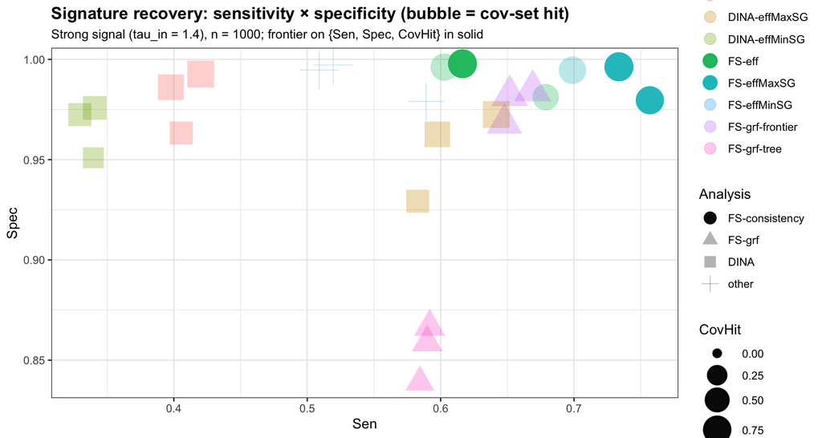

```r
plot_oc_metrics(
  display_dt[display_dt$tau_in == max(display_dt$tau_in), ],
  x = "Sen", y = "Spec", z = "CovHit",
  size_limits = c(0, 1),
  pareto_col  = "pareto_frontier",
  title    = "Signature recovery: sensitivity \u00d7 specificity (bubble = cov-set hit)",
  subtitle = sprintf("Strong signal (tau_in = %.1f), n = %d; frontier on {Sen, Spec, CovHit} in solid",
                     max(display_dt$tau_in), max(display_dt$n)))
```